# What happens to resting BTC orders on HyperLiquid when price moves

### Q2: Breakouts from a range

**Scope.** Ranges come from the product's 1Box engine on 1m candles, rebuilt separately for each odd day. **213 attempts on 16 odd days: 100 successes** (the mid got half a box beyond the edge within 30 min before a 1m close back inside: a median 13 bps; 11% of successes needed under 5 bps) and **113 failures**. Also 36 sweeps and 182 boundary tests. Controls: 542 ordinary ≥ 5 bps moves and 320 random seconds. Success, failure and even "attempt vs test" are known only after contact (**C**), so every class comparison describes what happened; none is a cue a trader could read.

On the Q2 cards the notebook adds the box geometry: **E** = the broken edge (solid), the far edge (dotted), the success barrier E + H/2 (dashed, H = the box height), and two moments: **t_x** = first contact with the edge, and **t_a** = the close of the 1Box *attempt bar*, the 1m bar at whose close the engine decides that the contact is an attempt rather than a boundary test (a median **43 s** after contact; failures 39 s). Everything drawn after t_x is hindsight for the class label.

```python
Q2F = pd.read_parquet(INTERIM / "q2_breakouts_data/features_enriched.parquet")
Q2X = pd.read_parquet(INTERIM / "q2_breakouts_data/card_extra_rows.parquet")
for d in pd.concat([Q2F.day, Q2X.eid.str[:8]]).unique():
    odd_day(d)
Q2EV = pd.concat([Q2F, Q2X], ignore_index=True).set_index("eid")
Q2EX = {e["key"]: e for e in json.loads((INTERIM / "q2_breakouts_data/examples.json").read_text())}


def q2_card(key, caption, title=None, post_s=None):
    """A Q2 example card, the section's window and geometry (t_x - pre_s -> t_x + post_s); `post_s`
    overrides the section's window end."""
    e = Q2EX[key]
    r = Q2EV.loc[e["eid"]]
    t0, t1 = int(r.t_x) - int(e["pre_s"]) * NS, int(r.t_x) + int(post_s or e["post_s"]) * NS
    s, E10, H10 = int(r.s), float(r.E10), float(r.H10)
    if r.kind == "control":
        ys, hl, vl = [E10], [(E10 / 10, "E (reference touch at the control second)")], [(int(r.t_x), "anchor")]
    else:
        ys = [E10, E10 - s * H10, E10 + s * 0.5 * H10]
        hl = [(E10 / 10, "E: the broken edge"), ((E10 - s * H10) / 10, "far edge", ":"),
              ((E10 + s * 0.5 * H10) / 10, "success barrier E + H/2", "--")]
        vl = [(int(r.t_x), "t_x first contact"), (int(r.t_a), "t_a")]
    if pd.notna(r.px_st) and t0 < int(r.t_st) < t1:
        ys.append(float(r.px_st))
        vl.append((int(r.t_st), "first extreme" if r.kind == "control" else "stall"))
    lo, hi = price_range(t0, t1, include=[y / 10 for y in ys], pad_frac=0.12)
    return render_card(t0, t1, lo, hi, title=title or e["title"].replace("\\$", "$"), hlines=hl,
                       vlines=vl, caption=caption)
```

#### 2.1 Depth just beyond the edge did not separate breaks that worked from those that failed

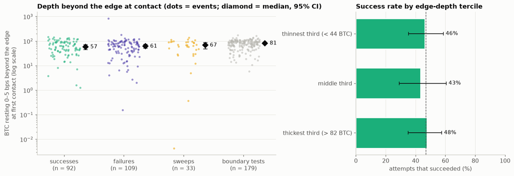

```
success minus failure, median depth: -4 BTC [-23, +15]; first attempt per box only: -6 BTC. Dashed line: the overall success rate (100 of 213).
```

```python
F1 = Q2["F1_target_depth"]
dc = Q2F[Q2F.x_hidT_bps > 21].copy()                      # the section's completeness gate
dc["depth"] = dc.x_tE_0_5 / 1e5
cls = [("SUCCESS", "successes", C["success"]), ("FAILED", "failures", C["failed"]),
       ("SWEEP", "sweeps", C["sweep"]), ("TEST", "boundary tests", C["test"])]
fig, axs = plt.subplots(1, 2, figsize=(13, 4.4), gridspec_kw={"width_ratios": [1.6, 1]})
ax = axs[0]
rng = np.random.default_rng(7)
for i, (k, lab, col) in enumerate(cls):
    v = dc[dc.cls == k].depth.to_numpy()
    ax.scatter(i + rng.uniform(-0.27, 0.27, v.size), v, s=14, color=col, alpha=0.55, lw=0)
    m = est(F1["x_tE_0_5_btc"][k])
    ax.errorbar(i + 0.36, m[0], yerr=[[m[0] - m[1]], [m[2] - m[0]]], fmt="D", ms=7, color=C["ink"],
                ecolor=C["ink"], capsize=4, elinewidth=1.3)
    ax.text(i + 0.44, m[0], f"{m[0]:.0f}", va="center", fontsize=9.5)
ax.set_yscale("log")
ax.set_xticks(range(4), [f"{lab}\n(n = {F1['x_tE_0_5_btc'][k]['n']})" for k, lab, _ in cls])
ax.set_ylabel("BTC resting 0–5 bps beyond the edge\nat first contact (log scale)")
ax.set_title("Depth beyond the edge at contact (dots = events; diamond = median, 95% CI)")
ax.grid(axis="x", visible=False)
ax = axs[1]
TT = F1["success_by_tE05_tercile"]
cuts = TT["cuts_btc"]
ci_bars(ax, [f"thinnest third (< {cuts[0]:.0f} BTC)", "middle third", f"thickest third (> {cuts[1]:.0f} BTC)"],
        [est(TT[f"T{i}"]) for i in (1, 2, 3)], C["success"], xlim=(0, 100),
        xlabel="attempts that succeeded (%)", ref=100 * 100 / 213)
ax.set_title("Success rate by edge-depth tercile")
plt.show()
dd = F1["diff_S_minus_F"]["x_tE_0_5_btc"]
print(f"success minus failure, median depth: {dd['diff']:+.0f} BTC [{dd['ci95'][0]:+.0f}, {dd['ci95'][1]:+.0f}]; "
      f"first attempt per box only: {F1['first_attempt_only']['diff_S_minus_F_x_tE_0_5_btc']['diff']:+.0f} BTC. "
      "Dashed line: the overall success rate (100 of 213).")
```

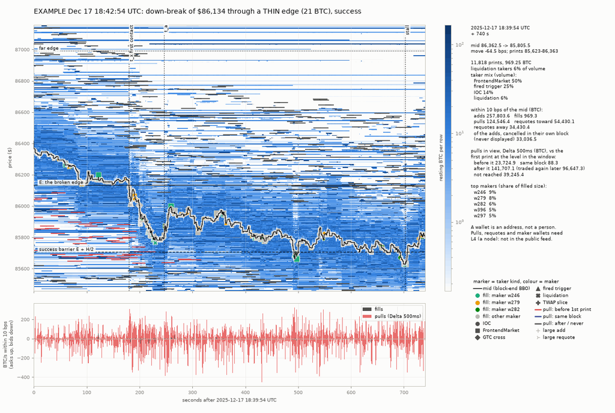

**What to look at:** very little resting below E at contact (21 BTC). This card runs to 9.3 min after contact (the section's card stops at 5 min, before the run), so the outcome is in view: price first crosses the success barrier (dashed) a little over 5 min after contact, just past where the section's card stops, and makes its first stall **59 bps below E, 8.7 min after contact** (the 'stall' line). The triangles in the first minute show what carried the break: fired stops were 184 BTC and liquidations 45 BTC of the first minute's 288 BTC.

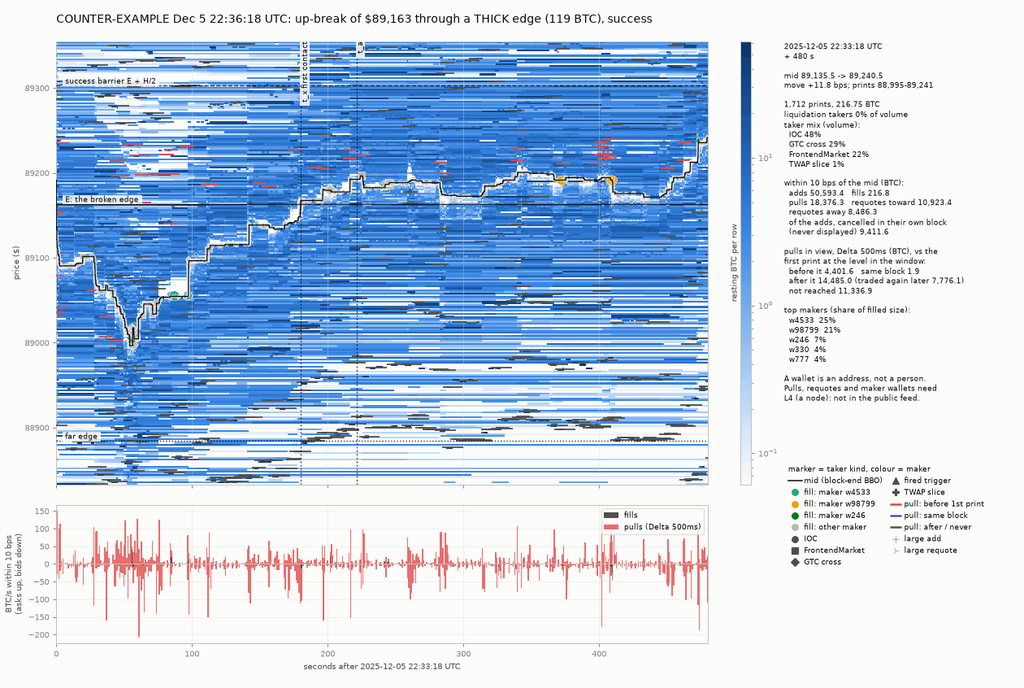

**What to look at:** a *thick* edge (119 BTC resting just above E at contact) that broke anyway.

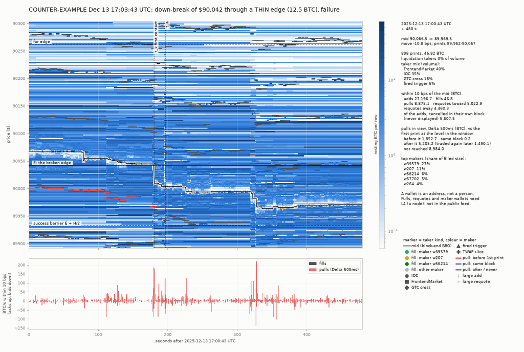

**What to look at:** a *thin* edge (12.5 BTC) and the break still failed: price comes back inside the box.

**Observation.** At first contact, resting depth 0–5 bps beyond the edge was 57 BTC [44–71] on successes vs 61 BTC [50–73] on failures: a difference of -4 BTC [-23, +15]. Success rate by depth tercile: 46% / 43% / 48%. First attempt per box only: -6 BTC [-25, +18]. The side being broken held ~0.3 of touch depth in every class.

**Interpretation.** On these 213 attempts a thin or thick book just past the edge was no guide to the outcome. Price moving toward the thinner side is ordinary geometry, not a breakout signature.

**Class.** **A** (the public book at $10 buckets covers 0–5 bps as 4–5 buckets).

```python
q2_card("f1_thin_success", "**What to look at:** very little resting below E at contact (21 BTC). This card "
        "runs to 9.3 min after contact (the section's card stops at 5 min, before the run), so the outcome "
        "is in view: price first crosses the success barrier (dashed) a little over 5 min after contact, just "
        "past where the section's card stops, and makes its first stall **59 bps below E, 8.7 min after "
        "contact** (the 'stall' line). The triangles in the first minute show what carried the break: "
        "fired stops were 184 BTC and liquidations 45 BTC of the first minute's 288 BTC.",
        title="EXAMPLE Dec 17 18:42:54 UTC: down-break of $86,134 through a THIN edge (21 BTC), success",
        post_s=560)
q2_card("f1_counter_thick_success", "**What to look at:** a *thick* edge (119 BTC resting just above E at "
        "contact) that broke anyway.",
        title="COUNTER-EXAMPLE Dec 5 22:36:18 UTC: up-break of $89,163 through a THICK edge (119 BTC), success")
q2_card("f1_counter_thin_failure", "**What to look at:** a *thin* edge (12.5 BTC) and the break still "
        "failed: price comes back inside the box.",
        title="COUNTER-EXAMPLE Dec 13 17:03:43 UTC: down-break of $90,042 through a THIN edge (12.5 BTC), failure")
note("At first contact, resting depth 0–5 bps beyond the edge was 57 BTC [44–71] on successes vs 61 BTC "
     "[50–73] on failures: a difference of -4 BTC [-23, +15]. Success rate by depth tercile: 46% / 43% / "
     "48%. First attempt per box only: -6 BTC [-25, +18]. The side being broken held ~0.3 of touch depth in "
     "every class.",
     "On these 213 attempts a thin or thick book just past the edge was no guide to the outcome. Price "
     "moving toward the thinner side is ordinary geometry, not a breakout signature.",
     "**A** (the public book at $10 buckets covers 0–5 bps as 4–5 buckets).")
```